# Phase 2 - Proyect Education Formal

# import libraries

```r
library(rpart)
library(rpart.plot)
library(arules)
library(haven)
```

# Read data from .sav

```r
estudiantes <- read_sav("data.sav")
head(estudiantes)
```

| Año | CodEstablecimiento | Departamento_F | Depto_mupio | Sector | Área | Sexo | Grado | Nivel | Pueblo_Per | Plan_Est | Jornada_Est | Resultado_F | Repitente | Graduando |
| --- | --- | --- | --- | --- | --- | --- | --- | --- | --- | --- | --- | --- | --- | --- |
| 2023 | 00-01-0521-46 | 1 | 0101 | 2 | 1 | 1 | 5 | 4 | 1 | 2 | 1 | 5 | 2 | 2 |
| 2023 | 09-09-0111-46 | 9 | 0909 | 2 | 1 | 1 | 4 | 4 | 1 | 4 | 9 | 5 | 2 | 1 |
| 2023 | 17-10-0211-45 | 17 | 1710 | 2 | 1 | 2 | 3 | 3 | 5 | 2 | 4 | 4 | 2 | 2 |
| 2023 | 17-10-2965-46 | 17 | 1710 | 2 | 1 | 2 | 4 | 4 | 5 | 1 | 2 | 4 | 2 | 2 |
| 2023 | 00-01-0810-46 | 1 | 0101 | 2 | 1 | 1 | 4 | 4 | 1 | 4 | 9 | 1 | 2 | 1 |
| 2023 | 16-08-0225-46 | 16 | 1608 | 2 | 1 | 1 | 4 | 4 | 1 | 1 | 2 | 1 | 2 | 2 |

```r
estudiantes
```

| Año | CodEstablecimiento | Departamento_F | Depto_mupio | Sector | Área | Sexo | Grado | Nivel | Pueblo_Per | Plan_Est | Jornada_Est | Resultado_F | Repitente | Graduando |
| --- | --- | --- | --- | --- | --- | --- | --- | --- | --- | --- | --- | --- | --- | --- |
| 2023 | 00-01-0521-46 | 1 | 0101 | 2 | 1 | 1 | 5 | 4 | 1 | 2 | 1 | 5 | 2 | 2 |
| 2023 | 09-09-0111-46 | 9 | 0909 | 2 | 1 | 1 | 4 | 4 | 1 | 4 | 9 | 5 | 2 | 1 |
| 2023 | 17-10-0211-45 | 17 | 1710 | 2 | 1 | 2 | 3 | 3 | 5 | 2 | 4 | 4 | 2 | 2 |
| 2023 | 17-10-2965-46 | 17 | 1710 | 2 | 1 | 2 | 4 | 4 | 5 | 1 | 2 | 4 | 2 | 2 |
| 2023 | 00-01-0810-46 | 1 | 0101 | 2 | 1 | 1 | 4 | 4 | 1 | 4 | 9 | 1 | 2 | 1 |
| 2023 | 16-08-0225-46 | 16 | 1608 | 2 | 1 | 1 | 4 | 4 | 1 | 1 | 2 | 1 | 2 | 2 |
| 2023 | 16-11-9092-46 | 16 | 1611 | 2 | 1 | 2 | 5 | 4 | 1 | 1 | 2 | 3 | 2 | 2 |
| 2023 | 16-12-0113-46 | 16 | 1612 | 2 | 1 | 2 | 5 | 4 | 1 | 1 | 2 | 3 | 2 | 2 |
| 2023 | 00-11-0841-45 | 1 | 0101 | 1 | 1 | 1 | 1 | 3 | 5 | 1 | 3 | 3 | 2 | 2 |
| 2023 | 00-13-8394-45 | 1 | 0101 | 1 | 1 | 1 | 1 | 3 | 5 | 1 | 3 | 3 | 2 | 2 |

[output cut: 990 more lines]

```r
estudiantes[estudiantes$Pueblo_Per == 5,]
```

| Año | CodEstablecimiento | Departamento_F | Depto_mupio | Sector | Área | Sexo | Grado | Nivel | Pueblo_Per | Plan_Est | Jornada_Est | Resultado_F | Repitente | Graduando |
| --- | --- | --- | --- | --- | --- | --- | --- | --- | --- | --- | --- | --- | --- | --- |
| 2023 | 17-10-0211-45 | 17 | 1710 | 2 | 1 | 2 | 3 | 3 | 5 | 2 | 4 | 4 | 2 | 2 |
| 2023 | 17-10-2965-46 | 17 | 1710 | 2 | 1 | 2 | 4 | 4 | 5 | 1 | 2 | 4 | 2 | 2 |
| 2023 | 00-11-0841-45 | 1 | 0101 | 1 | 1 | 1 | 1 | 3 | 5 | 1 | 3 | 3 | 2 | 2 |
| 2023 | 00-13-8394-45 | 1 | 0101 | 1 | 1 | 1 | 1 | 3 | 5 | 1 | 3 | 3 | 2 | 2 |
| 2023 | 20-07-0116-46 | 20 | 2007 | 2 | 1 | 2 | 4 | 4 | 5 | 2 | 4 | 4 | 2 | 2 |
| 2023 | 20-07-0149-46 | 20 | 2007 | 2 | 1 | 2 | 4 | 4 | 5 | 4 | 9 | 4 | 2 | 1 |
| 2023 | 22-04-0035-46 | 22 | 2204 | 2 | 1 | 1 | 4 | 4 | 5 | 1 | 2 | 4 | 2 | 2 |
| 2023 | 22-04-2085-46 | 22 | 2204 | 4 | 1 | 1 | 5 | 4 | 5 | 1 | 2 | 4 | 2 | 1 |
| 2023 | 00-12-9005-45 | 1 | 0101 | 2 | 1 | 1 | 3 | 3 | 5 | 2 | 4 | 4 | 2 | 2 |
| 2023 | 01-15-0283-45 | 1 | 0115 | 2 | 1 | 1 | 3 | 3 | 5 | 3 | 4 | 4 | 2 | 2 |

[output cut: 990 more lines]

# Decision tree

## Create Decision tree to get Pueblo de pertenencia

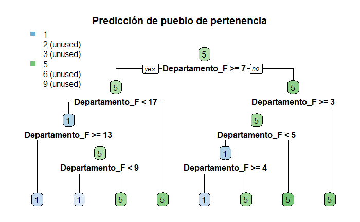

```r
arbol1 <- rpart(Pueblo_Per ~
               Sexo+
               Plan_Est+
               Jornada_Est+
               Área+
               Sector+
               Departamento_F,
               data = estudiantes, method = "class")

rpart.plot(arbol1, type=2, extra=0, under = TRUE, fallen.leaves = TRUE, box.palette = "BuGn",
           main ="Predicción de pueblo de pertenencia", cex = 1)
```

```r
estudiante <- data.frame(
   Sexo=c(1,2,1),
   Plan_Est=c(1,2,1),
   Jornada_Est=c(1,2,1),
   Área=c(2,1,2),
   Sector=c(3,1,3),
   Departamento_F=c(1,16,8)
)
predict(arbol1, estudiante, type="class")
```

```
1 2 3
5 1 1
Levels: 1 2 3 5 6 9
```

### Con el estudiante 1 y el 3 la única diferencia es el departamento uno es de Guatemala y otro de Totonicapan y es lo que hace que sea ladino o maya.

## Create Decision tree to get Pueblo de pertenencia without Departamento

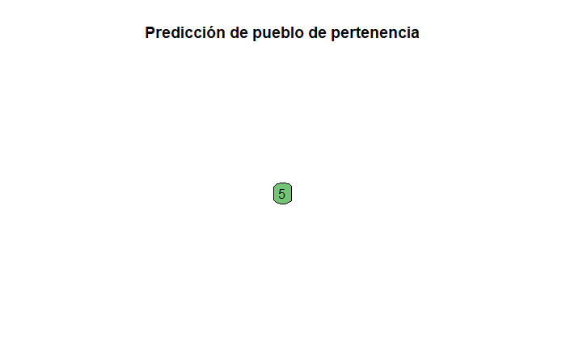

```r
arbol <- rpart(Pueblo_Per ~
               Sexo+
               Plan_Est+
               Jornada_Est+
               Área+
               Sector,
               data = estudiantes, method = "class")

rpart.plot(arbol, type=2, extra=0, under = TRUE, fallen.leaves = TRUE, box.palette = "BuGn",
           main ="Predicción de pueblo de pertenencia", cex = 1)
```

### Si quitamos el Departamento se dice que es más probable que sea ladino en general, ya que con las otras variables no se puede asignar si es ladino, maya, garifuna, Xinca u otro.

## Create Decision tree to get Área de pertenencia

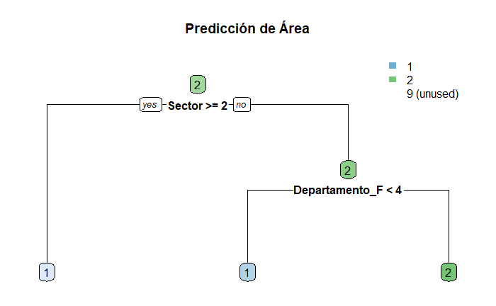

```r
arbol2 <- rpart(Área ~
               Sexo+
               Plan_Est+
               Jornada_Est+
               Pueblo_Per+
               Sector+
               Departamento_F,
               data = estudiantes, method = "class")

rpart.plot(arbol2, type=2, extra=0, under = TRUE, fallen.leaves = TRUE, box.palette = "BuGn",
           main ="Predicción de Área", cex = 1)
```

### Aquí realmente se puede verificar una de las reglas del apriori donde decía que el sector y el área estan relacionadas, donde si el sector es privado, municipal o cooperativa el área del estudiante es urbana, aunque aquí se extiende la relación donde decía que si el sector es público era rural, pues aquí es si el sector es publico y es del departamento de Guatemala, El progreso o Sacatepéquez sigue siendo urbano y si no es altamente probable rural.

```r
estudiante2 <- data.frame(
   Sexo=c(1,2,1),
   Plan_Est=c(1,2,1),
   Jornada_Est=c(1,2,1),
   Pueblo_Per=c(1,5,2),
   Sector=c(1,1,3),
   Departamento_F=c(1,16,8)
)
predict(arbol2, estudiante2, type="class")
```

```
1 2 3
1 2 1
Levels: 1 2 9
```

### Con el estudiante 1 y el 2 vemos que son del sector público, pero uno es de los 3 departamentos del centro del país, y el otro no, mientras el último es de un sector municipal, por lo que por eso es que uno obtiene Urbana, Rural y Urbana respectivamente.

## Create Decision tree to get Sector

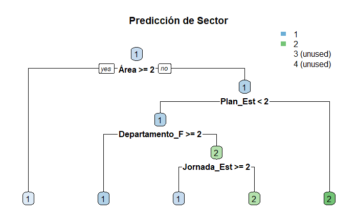

```r
arbol3 <- rpart(Sector ~
               Sexo+
               Plan_Est+
               Jornada_Est+
               Pueblo_Per+
               Área+
               Departamento_F,
               data = estudiantes, method = "class")

rpart.plot(arbol3, type=2, extra=0, under = TRUE, fallen.leaves = TRUE, box.palette = "BuGn",
           main ="Predicción de Sector", cex = 1)
```

### Aquí nos damos cuenta que el sector tiene relaciones más complejas, y que los sectores públicos y privados son los sobrepresentados como vimos en el análisis de la data de la fase 1, ya que solo se puede predecir si es público o privado el sector del alumno, donde si el área es rural entonces el sector es público, si el área es urbana y el plan de estudio no es diario entonces es privada, si el área es urbana, el plan de estudio es diario y el departamento no es la cápital es del sector público, pero si en este mismo caso es la capital y la jornada es matutina es privada si no es matutina es pública.

```r
estudiante3 <- data.frame(
   Sexo=c(1,2,1),
   Plan_Est=c(1,2,1),
   Jornada_Est=c(1,2,2),
   Pueblo_Per=c(1,5,2),
   Área=c(1,1,2),
   Departamento_F=c(2,16,8)
)
predict(arbol3, estudiante3, type="class")
```

```
1 2 3
1 2 1
Levels: 1 2 3 4
```

### Cómo vemos estos tres estudiantes solo fueron catalogados entre el sector público y privado.

## Create Decision tree to get Sexo

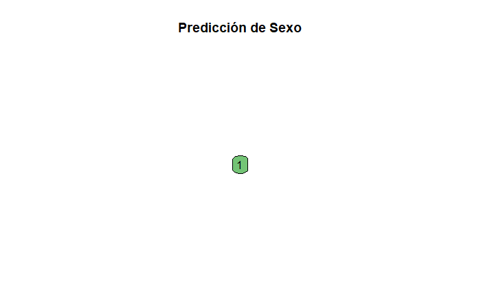

```r
arbol4 <- rpart(Sexo ~
               Sector+
               Plan_Est+
               Jornada_Est+
               Pueblo_Per+
               Área+
               Departamento_F,
               data = estudiantes, method = "class")

rpart.plot(arbol4, type=2, extra=0, under = TRUE, fallen.leaves = TRUE, box.palette = "BuGn",
           main ="Predicción de Sexo", cex = 1)
```

### Aquí se comprueba lo que en el análisis anterior se vio y parecio interesante, y es que el sexo no va ligado con otras variables, no se puede asumir si es hombre o mujer a partir de otras variables.

## Create Decision tree to get Jornada

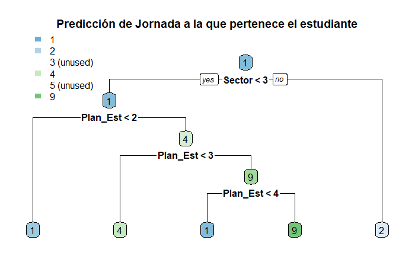

```r
arbol5 <- rpart(Jornada_Est ~
               Sector+
               Plan_Est+
               Sexo+
               Pueblo_Per+
               Área+
               Departamento_F,
               data = estudiantes, method = "class")

rpart.plot(arbol5, type=2, extra=0, under = TRUE, fallen.leaves = TRUE, box.palette = "BuGn",
           main ="Predicción de Jornada a la que pertenece el estudiante", cex = 1)
```

### Aquí se vicualiza que la jornada del estudiante depende principalmente del sector, donde si el sector no es publico o privado, la jornada es vespertina, si el sector es público o privado ya se complica el analisis, donde si el plan de estudio es diario o a distancia entonces la jornada es matutina, si el plan de estudio es fin de semana entonces la jornada es doble, si el plan de estudio es semipresencial o mixto la jornada no fue respondida.

```r
estudiante5 <- data.frame(
   Sexo=c(1,2,1,2),
   Plan_Est=c(1,2,1,5),
   Sector=c(1,2,3,1),
   Pueblo_Per=c(1,5,2,5),
   Área=c(1,1,2,2),
   Departamento_F=c(2,16,8,1)
)
predict(arbol5, estudiante5, type="class")
```

```
1 2 3 4
1 4 2 9
Levels: 1 2 3 4 5 9
```

### Cómo vemos estos 4 estudiantes tienen las caracteristicas necesarias según el arbol para que prediga si su jornada es matutina, doble, vespertina o ignorada. Donde parece ser que la jornada nocturna o intermedia no es usada mucho.

# Random Forest

```r
library(randomForest)
```

## Random Forest to get Pueblo de pertenencia

```r
estudiante2 <- estudiantes[,c("Pueblo_Per", "Sexo", "Plan_Est", "Jornada_Est", "Área", "Sector", "Departamento_F")]

estudiante2$Pueblo_Per <- as.factor(estudiante2$Pueblo_Per)

set.seed(100)
estudiante2 <- estudiante2[sample(1:nrow(estudiante2)),]

index <-sample(1:nrow(estudiante2), 0.8*nrow(estudiante2))

train <- estudiante2[index,]
test <- estudiante2[-index,]

bosque1 <- randomForest(Pueblo_Per ~
               Sexo+
               Plan_Est+
               Jornada_Est+
               Área+
               Sector+
               Departamento_F,
               data = train,
               ntree = 10,
               mtry = 4
            )
### Como podemos verificar, es que solo puede resolver casos para 1 y 5, ya que los ladinos y mayas están sobrerepresentados.
entreno <- predict(bosque1, test)
entreno
```

```
   1    2    3    4    5    6    7    8    9   10   11   12   13   14   15   16   17   18   19   20   21   22   23   24   25
   1    5    5    5    1    1    5    5    1    5    5    5    5    1    5    5    5    5    5    5    5    5    5    5    5
  26   27   28   29   30   31   32   33   34   35   36   37   38   39   40   41   42   43   44   45   46   47   48   49   50
   5    5    5    5    5    5    5    5    5    5    5    5    5    5    5    5    5    5    5    5    5    5    1    5    5
  51   52   53   54   55   56   57   58   59   60   61   62   63   64   65   66   67   68   69   70   71   72   73   74   75
   5    5    5    5    1    5    5    5    5    5    5    1    5    5    5    5    5    5    5    5    5    5    5    5    5
  76   77   78   79   80   81   82   83   84   85   86   87   88   89   90   91   92   93   94   95   96   97   98   99  100
   5    5    5    5    1    5    5    5    5    5    5    5    1    1    5    5    1    5    1    5    5    1    5    1    5
 101  102  103  104  105  106  107  108  109  110  111  112  113  114  115  116  117  118  119  120  121  122  123  124  125
   1    5    5    5    5    1    5    5    5    5    5    5    5    5    5    5    5    5    5    1    5    5    5    5    5
 126  127  128  129  130  131  132  133  134  135  136  137  138  139  140  141  142  143  144  145  146  147  148  149  150
   5    5    5    1    5    1    1    5    5    5    5    5    1    1    5    5    1    5    1    1    1    5    5    5    1
 151  152  153  154  155  156  157  158  159  160  161  162  163  164  165  166  167  168  169  170  171  172  173  174  175
   5    5    1    1    1    5    5    5    5    5    5    5    5    5    5    5    5    1    1    5    5    5    5    1    1
 176  177  178  179  180  181  182  183  184  185  186  187  188  189  190  191  192  193  194  195  196  197  198  199  200
```

[output cut: 67 more lines]

### Como podemos verificar, es que solo puede resolver casos para 1 y 5, ya que los ladinos y mayas están sobrerepresentados. Se hace con un número de arboles corto, ya que si no crece demasiado y da error de memoria.

```r
estudiante <- data.frame(
   Sexo=c(1,2,1),
   Plan_Est=c(1,2,1),
   Jornada_Est=c(1,2,1),
   Área=c(2,1,2),
   Sector=c(3,1,3),
   Departamento_F=c(1,16,8)
)
predict(bosque1, estudiante)
```

```
1 2 3
5 1 1
Levels: 1 2 3 5 6 9
```

### Tiene las mismas respuestas que el de el arbol normal en las mismas pruebas.

## Random Forest to get Área de pertenencia

```r
estudiante3 <- estudiantes[,c("Pueblo_Per", "Sexo", "Plan_Est", "Jornada_Est", "Área", "Sector", "Departamento_F")]

estudiante3$Área <- as.factor(estudiante3$Área)

set.seed(100)
estudiante3 <- estudiante3[sample(1:nrow(estudiante3)),]

index <-sample(1:nrow(estudiante3), 0.8*nrow(estudiante3))

train <- estudiante3[index,]
test <- estudiante3[-index,]

bosque2 <- randomForest(Área ~
               Sexo+
               Plan_Est+
               Jornada_Est+
               Pueblo_Per+
               Sector+
               Departamento_F,
               data = train,
               ntree = 20,
               mtry = 4
            )
entreno <- predict(bosque2, test)
entreno
```

```
   1    2    3    4    5    6    7    8    9   10   11   12   13   14   15   16   17   18   19   20   21   22   23   24   25
   2    2    2    1    2    2    1    1    2    1    1    2    2    2    1    2    1    1    2    1    1    1    1    1    1
  26   27   28   29   30   31   32   33   34   35   36   37   38   39   40   41   42   43   44   45   46   47   48   49   50
   2    1    2    1    1    1    1    1    2    2    2    2    2    2    1    1    1    1    2    1    2    1    2    2    1
  51   52   53   54   55   56   57   58   59   60   61   62   63   64   65   66   67   68   69   70   71   72   73   74   75
   2    2    2    1    2    1    1    2    2    2    1    2    2    2    1    1    2    1    2    1    2    1    2    1    2
  76   77   78   79   80   81   82   83   84   85   86   87   88   89   90   91   92   93   94   95   96   97   98   99  100
   1    1    2    1    2    1    1    2    2    2    2    1    2    1    1    1    2    2    2    2    2    1    1    2    2
 101  102  103  104  105  106  107  108  109  110  111  112  113  114  115  116  117  118  119  120  121  122  123  124  125
   2    2    2    2    1    2    1    2    2    2    1    1    2    2    2    1    2    2    2    1    1    2    1    2    1
 126  127  128  129  130  131  132  133  134  135  136  137  138  139  140  141  142  143  144  145  146  147  148  149  150
   2    2    1    2    1    2    2    2    1    2    2    2    2    2    2    1    2    1    2    2    1    1    1    2    2
 151  152  153  154  155  156  157  158  159  160  161  162  163  164  165  166  167  168  169  170  171  172  173  174  175
   1    1    1    2    2    2    1    2    2    2    2    2    1    2    2    2    2    2    2    1    1    2    2    2    1
 176  177  178  179  180  181  182  183  184  185  186  187  188  189  190  191  192  193  194  195  196  197  198  199  200
```

[output cut: 67 more lines]

### Se puede visualizar que los valores de respuesta son entre uno o dos, que tiene sentido ya que el Área es solo Urbana o Rural

```r
student2 <- data.frame(
   Sexo=c(1,2,1),
   Plan_Est=c(1,2,1),
   Jornada_Est=c(1,2,1),
   Pueblo_Per=c(1,5,2),
   Sector=c(1,1,3),
   Departamento_F=c(1,16,8)
)
predict(bosque2, student2)
```

```
1 2 3
2 1 1
Levels: 1 2 9
```

### En este caso tiene respuestas diferentes a la del arbol normal, ya que el primero dice ser rural, urbana y urbana, en cambio antes en el del arbol de decisión predecia que era urbana, rural, urbana

## Random Forest to get Sector

```r
estudiante4 <- estudiantes[,c("Pueblo_Per", "Sexo", "Plan_Est", "Jornada_Est", "Área", "Sector", "Departamento_F")]

estudiante4$Sector <- as.factor(estudiante4$Sector)

set.seed(100)
estudiante4 <- estudiante4[sample(1:nrow(estudiante4)),]

index <-sample(1:nrow(estudiante4), 0.8*nrow(estudiante4))

train <- estudiante4[index,]
test <- estudiante4[-index,]

bosque3 <- randomForest(Sector ~
               Sexo+
               Plan_Est+
               Jornada_Est+
               Pueblo_Per+
               Área+
               Departamento_F,
               data = train,
               ntree = 15,
               mtry = 4
            )
entreno <- predict(bosque3, test)
entreno
```

```
   1    2    3    4    5    6    7    8    9   10   11   12   13   14   15   16   17   18   19   20   21   22   23   24   25
   1    1    1    1    1    1    2    2    1    1    1    1    1    1    2    1    1    2    1    2    2    1    1    2    1
  26   27   28   29   30   31   32   33   34   35   36   37   38   39   40   41   42   43   44   45   46   47   48   49   50
   1    2    1    2    2    2    1    1    1    1    1    1    1    1    1    1    2    4    1    2    1    1    1    1    2
  51   52   53   54   55   56   57   58   59   60   61   62   63   64   65   66   67   68   69   70   71   72   73   74   75
   1    1    1    1    1    1    2    1    1    1    1    1    1    1    1    2    1    1    1    2    1    2    1    1    1
  76   77   78   79   80   81   82   83   84   85   86   87   88   89   90   91   92   93   94   95   96   97   98   99  100
   2    2    1    2    1    1    2    1    1    1    1    2    1    2    2    2    1    1    1    1    4    1    2    1    1
 101  102  103  104  105  106  107  108  109  110  111  112  113  114  115  116  117  118  119  120  121  122  123  124  125
   1    1    1    1    1    1    2    1    1    1    1    2    1    1    1    1    1    1    1    1    1    1    1    1    2
 126  127  128  129  130  131  132  133  134  135  136  137  138  139  140  141  142  143  144  145  146  147  148  149  150
   1    1    2    1    2    1    1    1    2    1    1    1    1    1    1    2    1    1    1    1    1    2    1    1    1
 151  152  153  154  155  156  157  158  159  160  161  162  163  164  165  166  167  168  169  170  171  172  173  174  175
   2    1    1    1    1    1    1    1    1    1    1    1    1    1    1    1    1    1    1    1    2    1    1    1    1
 176  177  178  179  180  181  182  183  184  185  186  187  188  189  190  191  192  193  194  195  196  197  198  199  200
```

[output cut: 67 more lines]

### Se puede visualizar que los valores de respuesta son entre 1 y 2, cómo en el arbol de decisión se visualiza un mayoritario 1 y 2 en las respuestas que es publico y privado, aunque aquí si se encuentra algún 4 que es Cooperativa

```r
student3 <- data.frame(
   Sexo=c(1,2,1),
   Plan_Est=c(1,2,1),
   Jornada_Est=c(1,2,2),
   Pueblo_Per=c(1,5,2),
   Área=c(1,1,2),
   Departamento_F=c(2,16,8)
)
predict(bosque3, student3)
```

```
1 2 3
1 2 1
Levels: 1 2 3 4
```

### En este caso en pocas combinaciones sería muy complicado encontrar el cuatro tomando en cuenta que en el arbol simple no muestra esta opción, y por los sujetos de muestra en los dos dan las mismas predicciones.

## Random Forest to get Sexo

```r
estudiante5 <- estudiantes[,c("Pueblo_Per", "Sexo", "Plan_Est", "Jornada_Est", "Área", "Sector", "Departamento_F")]

estudiante5$Sexo <- as.factor(estudiante5$Sexo)

set.seed(100)
estudiante5 <- estudiante5[sample(1:nrow(estudiante5)),]

index <-sample(1:nrow(estudiante5), 0.8*nrow(estudiante5))

train <- estudiante5[index,]
test <- estudiante5[-index,]

bosque4 <- randomForest(Sexo ~
               Sector+
               Plan_Est+
               Jornada_Est+
               Pueblo_Per+
               Área+
               Departamento_F,
               data = train,
               ntree = 15,
               mtry = 4
            )
entreno <- predict(bosque4, test)
entreno
```

```
   1    2    3    4    5    6    7    8    9   10   11   12   13   14   15   16   17   18   19   20   21   22   23   24   25
   1    2    1    1    1    1    1    1    1    1    2    1    2    1    2    2    2    2    1    1    1    2    2    2    1
  26   27   28   29   30   31   32   33   34   35   36   37   38   39   40   41   42   43   44   45   46   47   48   49   50
   1    2    2    1    1    1    2    1    1    2    1    1    1    1    2    1    2    2    1    1    1    1    1    1    1
  51   52   53   54   55   56   57   58   59   60   61   62   63   64   65   66   67   68   69   70   71   72   73   74   75
   1    1    1    2    1    1    2    1    1    1    1    1    1    1    1    1    1    1    1    1    1    1    1    2    1
  76   77   78   79   80   81   82   83   84   85   86   87   88   89   90   91   92   93   94   95   96   97   98   99  100
   1    1    1    2    1    1    2    1    2    1    1    1    1    2    2    2    1    1    1    1    1    2    1    1    1
 101  102  103  104  105  106  107  108  109  110  111  112  113  114  115  116  117  118  119  120  121  122  123  124  125
   1    1    1    1    1    1    1    1    1    1    1    2    1    2    2    1    1    1    1    2    1    1    1    1    1
 126  127  128  129  130  131  132  133  134  135  136  137  138  139  140  141  142  143  144  145  146  147  148  149  150
   1    1    2    1    1    1    1    2    2    1    1    1    1    1    2    2    1    1    1    1    1    2    2    2    1
 151  152  153  154  155  156  157  158  159  160  161  162  163  164  165  166  167  168  169  170  171  172  173  174  175
   1    2    1    1    2    1    2    2    1    1    1    1    1    1    2    1    2    1    1    1    2    1    1    2    1
 176  177  178  179  180  181  182  183  184  185  186  187  188  189  190  191  192  193  194  195  196  197  198  199  200
```

[output cut: 67 more lines]

```r
student4 <- data.frame(
   Sector=c(1,2,1),
   Plan_Est=c(1,2,4),
   Jornada_Est=c(1,2,2),
   Pueblo_Per=c(1,1,2),
   Área=c(1,2,2),
   Departamento_F=c(2,16,8)
)
predict(bosque4, student4)
```

```
1 2 3
2 1 2
Levels: 1 2 9
```

### En este caso podemos ver una distribución bastante igual ya que hay una representación muy par entre los sexos, aunque es interesante ya que haciendo pruebas solo me daban mujer como predicción, pero al cambiar el área y pueblo perteneciente, y ser maya y del área rural fue el factor que hizo que cambiara a que fuera hombre, habría que seguir haciendo varias combinaciones para probar este hecho, pero parece importante he interesante.

## Random Forest to get Jornada

```r
estudiante6 <- estudiantes[,c("Pueblo_Per", "Sexo", "Plan_Est", "Jornada_Est", "Área", "Sector", "Departamento_F")]

estudiante6$Jornada_Est <- as.factor(estudiante6$Jornada_Est)

set.seed(100)
estudiante6 <- estudiante6[sample(1:nrow(estudiante6)),]

index <-sample(1:nrow(estudiante6), 0.8*nrow(estudiante6))

train <- estudiante6[index,]
test <- estudiante6[-index,]

bosque5 <- randomForest(Jornada_Est ~
               Sector+
               Plan_Est+
               Sexo+
               Pueblo_Per+
               Área+
               Departamento_F,
               data = train,
               ntree = 20,
               mtry = 5
            )
entreno <- predict(bosque5, test)
entreno
```

```
   1    2    3    4    5    6    7    8    9   10   11   12   13   14   15   16   17   18   19   20   21   22   23   24   25
   1    1    1    1    1    1    1    1    1    1    1    1    1    1    1    1    1    1    1    1    1    1    1    1    1
  26   27   28   29   30   31   32   33   34   35   36   37   38   39   40   41   42   43   44   45   46   47   48   49   50
   1    1    1    1    1    1    1    1    1    1    1    1    1    1    1    1    4    2    1    1    1    1    1    1    1
  51   52   53   54   55   56   57   58   59   60   61   62   63   64   65   66   67   68   69   70   71   72   73   74   75
   1    1    1    1    1    1    1    1    1    1    1    1    1    1    1    1    1    1    1    4    1    1    1    1    1
  76   77   78   79   80   81   82   83   84   85   86   87   88   89   90   91   92   93   94   95   96   97   98   99  100
   9    1    1    1    1    2    4    1    1    1    1    1    1    1    4    1    1    1    1    1    1    1    4    1    1
 101  102  103  104  105  106  107  108  109  110  111  112  113  114  115  116  117  118  119  120  121  122  123  124  125
   1    1    1    1    1    1    1    1    1    1    1    1    1    1    1    1    1    1    1    1    1    1    1    1    1
 126  127  128  129  130  131  132  133  134  135  136  137  138  139  140  141  142  143  144  145  146  147  148  149  150
   1    1    1    1    4    1    1    1    1    1    1    1    1    1    2    1    1    1    1    1    1    4    1    1    1
 151  152  153  154  155  156  157  158  159  160  161  162  163  164  165  166  167  168  169  170  171  172  173  174  175
   1    2    1    1    1    1    1    1    1    1    1    1    1    1    1    1    1    2    1    2    1    1    1    1    1
 176  177  178  179  180  181  182  183  184  185  186  187  188  189  190  191  192  193  194  195  196  197  198  199  200
```

[output cut: 67 more lines]

### Se puede visualizar que los valores de predicción van del 1, 2, 4 y 9 principalmente como en el arbol de decisión, pero es una gran cantidad de posibilidad que sea Matutina, está sobrerepresentada, seguida por la vespertina y la doble, donde en fin de semana es que se vuelve factor clave para que sea doble.

```r
student5 <- data.frame(
   Sexo=c(1,2,1,2),
   Plan_Est=c(1,2,1,5),
   Sector=c(1,2,3,1),
   Pueblo_Per=c(1,5,2,5),
   Área=c(1,1,2,2),
   Departamento_F=c(2,16,8,1)
)
predict(bosque5, student5)
```

```
1 2 3 4
1 4 1 1
Levels: 1 2 3 4 5 9
```

### En este caso podemos ver que los resultados dados desde los mismos testeos con el arbol de decision no esta regresando lo mismo, en vez de regresar 1 4 2 9, regresó 1 4 1 1, siendo los últimos dos los diferentes, vamos a intentar obtener estos datos, vamos a ver como se podrían obtenerlos.

```r
student5 <- data.frame(
   Sexo=c(1,2,1,2),
   Plan_Est=c(1,2,1,4),
   Sector=c(1,2,4,1),
   Pueblo_Per=c(1,5,2,5),
   Área=c(1,1,2,2),
   Departamento_F=c(2,16,8,1)
)
predict(bosque5, student5)
```

```
1 2 3 4
1 4 2 9
Levels: 1 2 3 4 5 9
```

### Con plan estudiantil 4 que es semipresencial normalmente es cuando se obtiene que la jornada es indefinida osea 9, y uno de los factores principales para obtener que la jornada es vespertina es que el sector sea una cooperativa osea 4. Esto se hizo jugando con los datos hasta encontrar que variables tienen más peso para hacer la diferencia